# Collins College Retention and Enrollment

MSDM Group 3

Ruben Garcia

IBM 6500, Cal Poly Pomona

2026-10-04

# Table of Contents

1. Introduction
2. Literature Review
3. Methods
4. References

# Introduction

## Problem Statement

The Collins College of Hospitality Management (CCHM) at Cal Poly Pomona has real strengths: the PolyX teaching restaurant, wine, spirits and beer courses, a large alumni network, and the Hospitality Uncorked gala. Yet:

- Enrollment fell from about **1,204** students (2015-16) to about **434** (2025-26).
- Campus-wide enrollment stayed steady at about 28,000.
- Many students are not involved in events outside class, which may hurt retention.
- Communication channels do not consistently show what makes CCHM unique.

**Two connected problems**

CCHM must **attract** new students and **engage and retain** current ones.

## Enrollment Gap

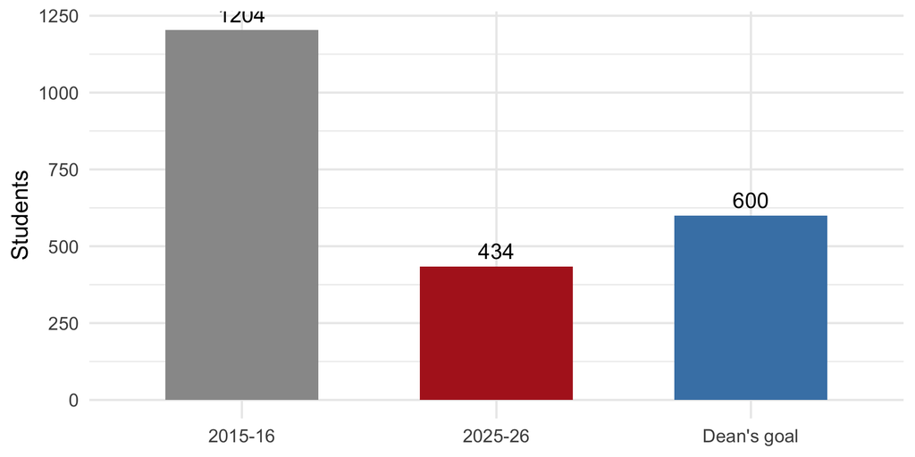

Figure 1: CCHM enrollment: past, present, and the Dean’s goal

## Analytics Objective

**AO1:** Measure engagement on Collins College Instagram **Reels and Stories** (views, saves, shares, follower growth) and compare it with student engagement, to see whether community-building content is linked to stronger **retention**.

- Focus: the positive psychology of posts, such as purpose, community, clubs, and the student experience
- Tied to **PO2** (retention) and **PO3** (awareness)

## Importance

- **PO1:** move enrollment toward the Dean’s goal of about 600 students
- **PO2:** raise engagement and sense of belonging, especially for first-time freshmen
- **PO3:** raise prospective students’ awareness of CCHM’s unique programs
- Social content that builds community could serve **all three** objectives at once

# Literature Review

## Consumer Behavior Theory

- **Sense of belonging:** students who feel connected to their college are more likely to persist
- **Positive psychology:** purpose and community as drivers of engagement
- **Student integration and retention models:** academic and social integration predict staying enrolled
- **Social media engagement:** likes, saves, and shares as signs of connection (Bae, Park, and Kim, 2023)

## Is the Data Adequate?

**What we have**

- Google Analytics 4 data
- Collins College Instagram analytics (via Professor Kwok)
- Event attendance
- Planned interviews and focus groups

**Gaps**

- Correlation between post engagement and event attendance completed separetly
- Long term retention and results may be unavailable as data will be finalized in the fall

## Is More Analysis Needed?

Yes. Quantitative metrics alone cannot explain **why** content works, so interviews add the reasons.

- Focus groups with hospitality undergraduates
- One-on-one interviews with CMAA leaders and alumni
- Goal: find what builds belonging, and surface challenges in the program (Anthony et al., 2023)

# Methods

## Data and Sampling

| Source | Type |
| --- | --- |
| Google Analytics 4 | Quantitative |
| Collins College Instagram analytics | Quantitative |
| Event attendance | Quantitative |
| Focus groups (hospitality undergraduates) | Qualitative |
| Interviews (CMAA leaders, alumni) | Qualitative |

- IRB approval required for student interviews
- Sampling Method will include 3 focus groups of 5 students each and a goal of 10 alumni interviews

## Data Wrangling

Initially before analysis; I will have to clean up the data and filter to specific parameters of specific social media posts and student attendance.

- Clean and standardize Instagram and GA4 exports
- Match the sources by date or time period
- Handle missing values
- Transcribe and code interview and focus group responses

## Sample Characteristics

Will include University underclassmen, specifically first year freshmen, seniors, and alumni of CPP Collins College

## Measures

- **Instagram:** views, saves, shares, follower growth (Reels and Stories)
- **Student engagement:** event attendance
- **Retention:** Enrollment Data for 2027
- **Belonging:** themes from interviews and focus groups

## Analytics Methods

- **Quantitative:** compare engagement metrics with student engagement and retention
- **Qualitative:** thematic analysis of interviews and focus groups
- **Together:** do community-building Reels and Stories line up with stronger retention?

# References